```python
import requests
import pandas as pd
from bs4 import BeautifulSoup
import urllib.request
import datetime
import locale
import dateparser
import warnings
import numpy as np
import matplotlib.pyplot as plt
import seaborn as sns
import random
from sklearn.model_selection import train_test_split
from sklearn.linear_model import LinearRegression
from sklearn.preprocessing import StandardScaler, LabelEncoder
from sklearn.metrics import r2_score, accuracy_score
from sklearn.decomposition import PCA
from sklearn.linear_model import LassoCV
from sklearn.linear_model import Lasso
from ipyleaflet import Map,LegendControl,Marker, LayersControl, Polyline
import matplotlib.colors as colors
```

### The whole project is a single-handed non-stop round the world yacht race. In order to study its potential influence among all the parameters, it is divided into three parts: first we collect all the necessary data from website. And a pre-processing work is dones in the second part. Finally, we analysed the obtained dataset from different aspects and draw a conclusion in the end.

# 1. Acquisition et chargement des données

### In this part, we will fisrtly collect all the excel files from the website using beautifulsoup and urllib library. Secondly, we will scrap the website to get a technical file about boat's information for each skipper.

### a. Récupération des fichiers Excel avec les classements

```python
# download the Excel file of rank by using url
def download_url(url):
    name = url.split('/')[-1]
    urllib.request.urlretrieve(url, f'/Users/delin/Desktop/final_projet/classement/{name}')
```

```python
# from the website classement, download historical rank Excel file
def get_classement_list(url):
    classement_list = []
    res = requests.get(url)
    soup = BeautifulSoup(res.content,'html.parser')
    dates = soup.find_all('option')
    names = dates[1:]
    # choose how many files we want
    for t in names:
        name = t.get('value')
        name_classement = f'vendeeglobe_{name}.xlsx'
        link = f'https://www.vendeeglobe.org/download-race-data/vendeeglobe_{name}.xlsx'
        try:
            download_url(link)
            classement_list.append(name_classement)
        except OSError as e:
            print(name, "error")
    return classement_list
```

```python
url = 'https://www.vendeeglobe.org/fr/classement'
classement_list = get_classement_list(url)
```

### b. Extraction des fiches techniques pour chacun des voiliers

```python
# obtain technique dataframe from the websit 'Glossaire' by using BeautifulSoup
def get_fiche_technique(url):
    res = requests.get(url)
    soup = BeautifulSoup(res.content,'html.parser')
    fichier_tech = soup.find_all('div', class_ = "sv-u-1 sv-u-s-1-2 sv-u-m-1-3 sv-u-l-1-6")
    df = pd.DataFrame()
    data = []
    for t in fichier_tech:
        l = []
        a = []
        skipper = t.find('span', class_='boats-list__skipper-name').text
        boat = t.find('h3', class_='boats-list__boat-name').text
        l = [skipper, boat]
        boat_info = t.find('ul', class_='boats-list__popup-specs-list').text.strip().split('\n')
        a = ['None']*14
        ref = ['Numéro de voile',
         'Anciens noms du bateau',
         'Architecte',
         'Chantier',
         'Date de lancement',
         'Longueur',
         'Largeur',
         "Tirant d'eau",
         'Déplacement (poids)',
         'Nombre de dérives',
         'Hauteur mât',
         'Voile quille',
         'Surface de voiles au près',
         'Surface de voiles au portant']
        for i in range(len(boat_info)):
            name = boat_info[i].split(': ')[0].strip()
            variable = boat_info[i].split(': ')[1]
            ind = ref.index(name)
            a[ind] = variable
        l = l + a
        data.append(l)

    name = ['Skipper', 'Bateau'] + ref
    df = pd.DataFrame(data, columns = name)
    return df
```

```python
url = "https://www.vendeeglobe.org/fr/glossaire"
df_tech = get_fiche_technique(url)
```

```python
df_tech[:2]
```

|  | Skipper | Bateau | Numéro de voile | Anciens noms du bateau | Architecte | Chantier | Date de lancement | Longueur | Largeur | Tirant d'eau | Déplacement (poids) | Nombre de dérives | Hauteur mât | Voile quille | Surface de voiles au près | Surface de voiles au portant |
| --- | --- | --- | --- | --- | --- | --- | --- | --- | --- | --- | --- | --- | --- | --- | --- | --- |
| 0 | Fabrice AMEDEO | NEWREST - ART & FENÊTRES | FRA 56 | No Way Back, Vento di Sardegna | VPLP/Verdier | Persico Marine | 01 Août 2015 | 18,28 m | 5,85 m | 4,50 m | 7 t | foils | 29 m | monotype | 320 m2 | 570 m2 |
| 1 | Romain ATTANASIO | PURE - Best Western® | FRA 49 | Gitana Eighty, Synerciel, Newrest-Matmut | Bruce Farr Design | Southern Ocean Marine (Nouvelle Zélande) | 08 Mars 2007 | 18,28m | 5,80m | 4,50m | 9t | 2 | 28m | acier forgé | 280 m2 | 560 m2 |

# 2. Préparation des données

### In this part, we will pre-process two different dataset, like change columns' data types, insert or delete some columns, seperate value and units etc. Next, we will combine the ranking dataframe with the technics dataframe which is a preparation for the next step.

### a. Préparation des données Excel avec les classements

```python
# fonction to convert latitude and longitude
def convert(tude):
    deg = int(tude.split('°')[0])
    mn = float(tude.split('°')[1].split("'")[0])
    if tude[-1] in ['N', 'E']:
        multiplier = 1
    else:
        multiplier = -1
    return multiplier * (deg + mn / 60)
```

```python
# pre-processing on Excel dataframe
def traitement_excel(filename):
    df = pd.read_excel(filename, header=[3,4]).iloc[0:32,1:]
    col_name = (('Rang', ''),
            ('Nat. / Voile', ''),
            ('Skipper / Bateau', ''),
            ('Heure FR', ''),
            ('Latitude', ''),
            ('Longitude', ''),
            ('Depuis 30 minutes', 'Cap'),
            ('Depuis 30 minutes', 'Vitesse / kts'),
            ('Depuis 30 minutes', 'VMG / kts'),
            ('Depuis 30 minutes', 'Distance / nm'),
            ('Depuis le dernier classement', 'Cap'),
            ('Depuis le dernier classement', 'Vitesse / kts'),
            ('Depuis le dernier classement', 'VMG / kts'),
            ('Depuis le dernier classement', 'Distance / nm'),
            ('Depuis 24 heures', 'Cap'),
            ('Depuis 24 heures', 'Vitesse / kts'),
            ('Depuis 24 heures', 'VMG / kts'),
            ('Depuis 24 heures', 'Distance / nm'),
            ('DTF / nm', ''),
            ('DTL / nm', ''))
    df.columns = pd.MultiIndex.from_tuples(col_name)
    # remove units for speed, distance etc
    df['Latitude'] = df['Latitude'].apply(lambda x: convert(x))
    df['Longitude'] = df['Longitude'].apply(lambda x: convert(x))
    a = [x for x in range(6, df.shape[1])]
    l = [3] + a
    for i in l:
             df.iloc[:, i] = df.iloc[:, i].apply(lambda x: x.split(' ')[0])
             df.iloc[:, i] = df.iloc[:, i].apply(lambda x: x.split('°')[0])
    # create four new columns which sperate variables nation, voile, skipper and bateau
    df.insert(2, 'Nation', df['Nat. / Voile'].apply(lambda x: x.split(' ')[0].split('\n')[1]))
    df.insert(3, 'Voile', df['Nat. / Voile'].apply(lambda x: x.split(' ')[1]))
    df.insert(5, 'Skipper', df['Skipper / Bateau'].apply(lambda x: x.split('\n')[0]))
    df.insert(6, 'Bateau', df['Skipper / Bateau'].apply(lambda x: x.split('\n')[1]))
    # convert numerical varibale to numeric type
    a = [x for x in range(10, df.shape[1])]
    l = [0, 3] + a
    for i in l:
             df.iloc[:, i] = pd.to_numeric(df.iloc[:, i])
    # convert and complete Heure FR with datetime
    da = filename.split('/')[-1].split('_')[1]
    df['date'] = f'{da[0:4]}-{da[4:6]}-{da[6:]}'
    df['Heure FR'] = pd.to_datetime(df['date']+' '+df['Heure FR'])
    # change data type for other variables:
    l = [2, 5, 6]
    for i in l:
             df.iloc[:, i] = df.iloc[:, i].astype(str)
    df['Skipper'] = df['Skipper'].apply(lambda x: x.capitalize())
    df = df.drop(df.loc[df['Skipper']== 'Nicolas troussel'].index)

    return df
```

```python
# rank file on 2020/11/23 14:00
filename='/Users/delin/Desktop/final_projet/classement/vendeeglobe_20201123_140000.xlsx'
df_classement = traitement_excel(filename)
```

```python
# view of dataframe df_classement
df_classement
```

|  | Rang | Nat. / Voile | Nation | Voile | Skipper / Bateau | Skipper | Bateau | Heure FR | Latitude | Longitude | ... | Depuis le dernier classement Vitesse / kts | Depuis le dernier classement VMG / kts | Depuis le dernier classement Distance / nm | Depuis 24 heures Cap | Depuis 24 heures Vitesse / kts | Depuis 24 heures VMG / kts | Depuis 24 heures Distance / nm | DTF / nm | DTL / nm | date |
| --- | --- | --- | --- | --- | --- | --- | --- | --- | --- | --- | --- | --- | --- | --- | --- | --- | --- | --- | --- | --- | --- |
| 0 | 1 | \nFRA 79 | FRA | 79 | Charlie Dalin\nAPIVIA | Charlie dalin | APIVIA | 2020-11-23 14:30:00 | -29.849667 | -21.008667 | ... | 17.6 | 17.1 | 61.5 | 139 | 11.6 | 11.4 | 279.2 | 19421.4 | 0.0 | 2020-11-23 |
| 1 | 2 | \nFRA 59 | FRA | 59 | Thomas Ruyant\nLinkedOut | Thomas ruyant | LinkedOut | 2020-11-23 14:30:00 | -29.636167 | -21.493833 | ... | 15.7 | 14.7 | 55.0 | 148 | 9.7 | 9.1 | 231.7 | 19449.4 | 28.0 | 2020-11-23 |
| 2 | 3 | \nFRA 01 | FRA | 1 | Jean Le Cam\nYes we Cam ! | Jean le cam | Yes we Cam ! | 2020-11-23 14:30:00 | -25.603833 | -23.335833 | ... | 13.1 | 13.1 | 45.8 | 150 | 10.5 | 10.5 | 252.9 | 19691.4 | 270.0 | 2020-11-23 |
| 3 | 4 | \nFRA 85 | FRA | 85 | Kevin Escoffier\nPRB | Kevin escoffier | PRB | 2020-11-23 14:30:00 | -26.244667 | -24.730000 | ... | 9.2 | 9.2 | 32.3 | 135 | 10.7 | 10.7 | 256.9 | 19710.5 | 289.1 | 2020-11-23 |
| 4 | 5 | \nGBR 99 | GBR | 99 | Alex Thomson\nHUGO BOSS | Alex thomson | HUGO BOSS | 2020-11-23 14:30:00 | -26.107833 | -26.100333 | ... | 3.7 | 3.7 | 12.8 | 141 | 3.2 | 3.1 | 76.7 | 19772.2 | 350.8 | 2020-11-23 |
| 5 | 6 | \nMON 10 | MON | 10 | Boris Herrmann\nSeaexplorer - Yacht Club De Mo... | Boris herrmann | Seaexplorer - Yacht Club De Monaco | 2020-11-23 14:30:00 | -25.439833 | -25.543000 | ... | 11.3 | 11.2 | 39.4 | 135 | 9.7 | 9.7 | 232.8 | 19775.6 | 354.3 | 2020-11-23 |
| 6 | 7 | \nFRA 17 | FRA | 17 | Yannick Bestaven\nMaître Coq IV | Yannick bestaven | Maître Coq IV | 2020-11-23 14:30:00 | -25.216833 | -25.420167 | ... | 11.2 | 11.2 | 39.2 | 144 | 10.0 | 10.0 | 239.6 | 19780.4 | 359.1 | 2020-11-23 |
| 7 | 8 | \nFRA 18 | FRA | 18 | Louis Burton\nBureau Vallée 2 | Louis burton | Bureau Vallée 2 | 2020-11-23 14:30:00 | -26.110833 | -26.743000 | ... | 8.3 | 6.8 | 29.1 | 138 | 10.1 | 10.0 | 243.1 | 19799.1 | 377.8 | 2020-11-23 |
| 8 | 9 | \nFRA 4 | FRA | 4 | Sébastien Simon\nARKEA PAPREC | Sébastien simon | ARKEA PAPREC | 2020-11-23 14:30:00 | -25.339500 | -26.610667 | ... | 9.0 | 8.9 | 31.4 | 133 | 8.9 | 8.9 | 213.9 | 19822.7 | 401.3 | 2020-11-23 |
| 9 | 10 | \nFRA 109 | FRA | 109 | Samantha Davies\nInitiatives - Coeur | Samantha davies | Initiatives - Coeur | 2020-11-23 14:30:00 | -24.934167 | -27.307000 | ... | 9.7 | 9.2 | 34.1 | 145 | 9.3 | 9.1 | 222.3 | 19867.3 | 446.0 | 2020-11-23 |
| 10 | 11 | \nFRA 09 | FRA | 9 | Benjamin Dutreux\nOMIA - Water Family | Benjamin dutreux | OMIA - Water Family | 2020-11-23 14:30:00 | -21.603333 | -28.216000 | ... | 11.7 | 11.1 | 41.1 | 171 | 11.5 | 10.7 | 277.2 | 20044.9 | 623.6 | 2020-11-23 |
| 11 | 12 | \nFRA 1000 | FRA | 1000 | Damien Seguin\nGroupe APICIL | Damien seguin | Groupe APICIL | 2020-11-23 14:30:00 | -21.424833 | -28.781667 | ... | 11.1 | 10.7 | 38.7 | 166 | 10.9 | 10.3 | 262.6 | 20073.5 | 652.2 | 2020-11-23 |
| 12 | 13 | \nITA 34 | ITA | 34 | Giancarlo Pedote\nPrysmian Group | Giancarlo pedote | Prysmian Group | 2020-11-23 14:30:00 | -21.634167 | -29.295833 | ... | 11.7 | 11.3 | 41.1 | 158 | 10.5 | 10.2 | 252.6 | 20083.4 | 662.0 | 2020-11-23 |
| 13 | 14 | \nFRA 53 | FRA | 53 | Maxime Sorel\nV And B Mayenne | Maxime sorel | V And B Mayenne | 2020-11-23 14:30:00 | -18.023000 | -28.781500 | ... | 12.2 | 12.0 | 42.8 | 167 | 11.6 | 11.2 | 277.4 | 20238.2 | 816.9 | 2020-11-23 |
| 14 | 15 | \nFRA 27 | FRA | 27 | Isabelle Joschke\nMACSF | Isabelle joschke | MACSF | 2020-11-23 14:30:00 | -17.560333 | -28.810333 | ... | 12.9 | 12.6 | 45.0 | 165 | 12.2 | 11.9 | 291.8 | 20262.7 | 841.4 | 2020-11-23 |
| 15 | 16 | \nFRA 30 | FRA | 30 | Clarisse Cremer\nBanque Populaire X | Clarisse cremer | Banque Populaire X | 2020-11-23 14:30:00 | -16.126500 | -29.950333 | ... | 10.5 | 8.9 | 36.7 | 179 | 13.5 | 12.4 | 324.0 | 20370.4 | 949.0 | 2020-11-23 |
| 16 | 17 | \nFRA 49 | FRA | 49 | Romain Attanasio\nPure - Best Western Hotels a... | Romain attanasio | Pure - Best Western Hotels and Resorts | 2020-11-23 14:30:00 | -15.759167 | -30.426333 | ... | 12.6 | 9.9 | 44.1 | 182 | 12.9 | 11.5 | 308.8 | 20403.6 | 982.2 | 2020-11-23 |
| 17 | 18 | \nSUI 7 | SUI | 7 | Alan Roura\nLa Fabrique | Alan roura | La Fabrique | 2020-11-23 14:30:00 | -15.158000 | -30.604167 | ... | 12.7 | 11.1 | 44.5 | 181 | 12.9 | 11.6 | 310.3 | 20439.7 | 1018.3 | 2020-11-23 |
| 18 | 19 | \nFRA 92 | FRA | 92 | Stéphane Le Diraison\nTime For Oceans | Stéphane le diraison | Time For Oceans | 2020-11-23 14:30:00 | -10.188833 | -30.695333 | ... | 10.7 | 9.4 | 37.3 | 181 | 12.4 | 11.5 | 297.1 | 20705.2 | 1283.9 | 2020-11-23 |
| 19 | 20 | \nGBR 777 | GBR | 777 | Pip Hare\nMedallia | Pip hare | Medallia | 2020-11-23 14:30:00 | -0.205333 | -30.310167 | ... | 10.8 | 9.1 | 37.7 | 197 | 10.1 | 8.7 | 241.6 | 21257.0 | 1835.6 | 2020-11-23 |
| 20 | 21 | \nESP 33 | ESP | 33 | Didac Costa\nOne Planet One Ocean | Didac costa | One Planet One Ocean | 2020-11-23 14:30:00 | 0.263833 | -29.367333 | ... | 10.3 | 9.0 | 36.0 | 197 | 9.4 | 8.2 | 226.7 | 21268.0 | 1846.6 | 2020-11-23 |
| 21 | 22 | \nFRA 14 | FRA | 14 | Arnaud Boissieres\nLa Mie Câline - Artisans Ar... | Arnaud boissieres | La Mie Câline - Artisans Artipôle | 2020-11-23 14:30:00 | 0.005167 | -30.394167 | ... | 10.7 | 9.0 | 37.4 | 199 | 10.3 | 8.6 | 246.9 | 21270.6 | 1849.2 | 2020-11-23 |
| 22 | 23 | \nFRA 71 | FRA | 71 | Manuel Cousin\nGroupe Sétin | Manuel cousin | Groupe Sétin | 2020-11-23 14:30:00 | 0.770833 | -30.191000 | ... | 10.2 | 8.5 | 35.7 | 198 | 9.6 | 8.2 | 231.3 | 21311.0 | 1889.6 | 2020-11-23 |
| 23 | 24 | FR\nFRA 02 | FRA | 2 | Armel Tripon\nL'Occitane en Provence | Armel tripon | L'Occitane en Provence | 2020-11-23 14:30:00 | 2.645500 | -30.954500 | ... | 12.7 | 8.7 | 44.5 | 203 | 10.3 | 8.2 | 246.8 | 21432.0 | 2010.6 | 2020-11-23 |
| 24 | 25 | \nFRA 72 | FRA | 72 | Alexia Barrier\nTSE - 4myplanet | Alexia barrier | TSE - 4myplanet | 2020-11-23 14:30:00 | 6.562167 | -27.352167 | ... | 10.4 | 10.0 | 36.5 | 183 | 5.5 | 5.3 | 131.0 | 21609.3 | 2187.9 | 2020-11-23 |
| 25 | 26 | \nFRA 50 | FRA | 50 | Miranda Merron\nCampagne de France | Miranda merron | Campagne de France | 2020-11-23 14:30:00 | 6.353333 | -28.518833 | ... | 8.7 | 7.2 | 30.3 | 186 | 6.6 | 6.3 | 157.2 | 21610.8 | 2189.4 | 2020-11-23 |
| 26 | 27 | \nFRA 83 | FRA | 83 | Clément Giraud\nCompagnie du lit - Jiliti | Clément giraud | Compagnie du lit - Jiliti | 2020-11-23 14:30:00 | 6.538333 | -27.957333 | ... | 8.3 | 7.5 | 29.1 | 183 | 5.4 | 5.2 | 129.7 | 21614.8 | 2193.4 | 2020-11-23 |
| 27 | 28 | \nFIN 222 | FIN | 222 | Ari Huusela\nStark | Ari huusela | Stark | 2020-11-23 14:30:00 | 6.714833 | -27.116167 | ... | 8.3 | 7.9 | 29.2 | 171 | 6.6 | 6.6 | 158.8 | 21615.8 | 2194.4 | 2020-11-23 |
| 28 | 29 | FR\nFRA 69 | FRA | 69 | Sébastien Destremau\nMerci | Sébastien destremau | Merci | 2020-11-23 14:30:00 | 6.594500 | -28.230167 | ... | 8.8 | 8.6 | 30.8 | 188 | 7.0 | 6.7 | 168.3 | 21621.4 | 2200.0 | 2020-11-23 |
| 29 | 30 | \nFRA 56 | FRA | 56 | Fabrice Amedeo\nNewrest - Art et Fenetres | Fabrice amedeo | Newrest - Art et Fenetres | 2020-11-23 14:30:00 | 6.470500 | -28.949333 | ... | 6.2 | 5.9 | 21.6 | 176 | 6.5 | 6.4 | 155.3 | 21623.2 | 2201.8 | 2020-11-23 |
| 30 | 31 | \nJPN 11 | JPN | 11 | Kojiro Shiraishi\nDMG MORI Global One | Kojiro shiraishi | DMG MORI Global One | 2020-11-23 14:30:00 | 9.398167 | -28.663000 | ... | 13.2 | 13.1 | 46.1 | 174 | 11.6 | 11.5 | 277.6 | 21791.4 | 2370.0 | 2020-11-23 |
| 31 | 32 | \nFRA 8 | FRA | 8 | Jérémie Beyou\nCharal | Jérémie beyou | Charal | 2020-11-23 14:30:00 | 19.631667 | -20.358000 | ... | 12.5 | 12.4 | 43.8 | 185 | 15.3 | 15.2 | 367.7 | 22407.3 | 2985.9 | 2020-11-23 |

32 rows × 25 columns

### B. Préparation des données avec fiche_techinique

```python
# Pre-processing on data of technic file
def traitement_fiche_tech(df):
    pd.options.mode.chained_assignment = None
    # replace comma to dot
    df = df.apply(lambda x: x.str.replace(',', '.'))
    # convert date de lancement to datetime type
    df['Date de lancement'] = df['Date de lancement'].apply(lambda x: dateparser.parse(x).date())
    df['Date de lancement'] = pd.to_datetime(df['Date de lancement'])
    # convert variable to numerical type
    l = [7, 8, 9, 12, 14, 15]
    for i in l:
        df.iloc[:, i] = df.iloc[:, i].apply(lambda x: x.split('m')[0])
        df.iloc[:, i] = pd.to_numeric(df.iloc[:, i])
    df.iloc[:, 10] = df.iloc[:, 10].apply(lambda x: x.split('t')[0])
    # uniform 'skipper' format
    df['Skipper'] = df['Skipper'].apply(lambda x: x.capitalize())
    # since 'Nicolas Troussel' didn't participate in contest, we remove him
    df = df.drop(df.loc[df['Skipper']== 'Nicolas troussel'].index)
    # some irregular Skipper name
    df['Skipper'][df.loc[df['Skipper']=='Sam davies'].index] = 'Samantha davies'
    df['Skipper'][df.loc[df['Skipper']=='Alan  roura'].index] = 'Alan roura'
    df['Skipper'][df.loc[df['Skipper']=='Arnaud boissières'].index] = 'Arnaud boissieres'
    # change df to multiIndex in order to be coherent with fiche classement
    df.columns = pd.MultiIndex.from_product([df.columns, ['']])
    return df
```

```python
# apply function to dataframe
df_technique = traitement_fiche_tech(df_tech)
```

```python
# view of dataframe df_technique
df_technique[:2]
```

|  | Skipper | Bateau | Numéro de voile | Anciens noms du bateau | Architecte | Chantier | Date de lancement | Longueur | Largeur | Tirant d'eau | Déplacement (poids) | Nombre de dérives | Hauteur mât | Voile quille | Surface de voiles au près | Surface de voiles au portant |
| --- | --- | --- | --- | --- | --- | --- | --- | --- | --- | --- | --- | --- | --- | --- | --- | --- |
| 0 | Fabrice amedeo | NEWREST - ART & FENÊTRES | FRA 56 | No Way Back. Vento di Sardegna | VPLP/Verdier | Persico Marine | 2015-08-01 | 18.28 | 5.85 | 4.5 | 7 | foils | 29.0 | monotype | 320 | 570 |
| 1 | Romain attanasio | PURE - Best Western® | FRA 49 | Gitana Eighty. Synerciel. Newrest-Matmut | Bruce Farr Design | Southern Ocean Marine (Nouvelle Zélande) | 2007-03-08 | 18.28 | 5.80 | 4.5 | 9 | 2 | 28.0 | acier forgé | 280 | 560 |

```python
# check data types after processing
df_technique.dtypes
```

```
Skipper                                   object
Bateau                                    object
Numéro de voile                           object
Anciens noms du bateau                    object
Architecte                                object
Chantier                                  object
Date de lancement                 datetime64[ns]
Longueur                                 float64
Largeur                                  float64
Tirant d'eau                             float64
Déplacement (poids)                       object
Nombre de dérives                         object
Hauteur mât                              float64
Voile quille                              object
Surface de voiles au près                  int64
Surface de voiles au portant               int64
dtype: object
```

### C. Rapprochement des données des voiliers avec celle des classements.

```python
# merge two dataframes on 'Skipper' name
def merge_voile_classement(fiche_tech, fiche_classement):
    df_merge = pd.DataFrame()
    df1 = fiche_tech.copy()
    df2 = fiche_classement.copy()
    df_merge = pd.merge(df2, df1, how='left', on='Skipper')
    return df_merge
```

```python
warnings.simplefilter(action='ignore', category=pd.errors.PerformanceWarning)
df_merge = merge_voile_classement(df_technique, df_classement)
```

```python
# check if we well merged two dataframes
print("shape of technic file is:", df_technique.shape,
      "\nshape of rank file is", df_classement.shape,
      "\nshape of merge file is", df_merge.shape)
```

```
shape of technic file is: (32, 16)
shape of rank file is (32, 25)
shape of merge file is (32, 40)
```

```python
# view of dataframe df_merge
df_merge[:2]
```

|  | Rang | Nat. / Voile | Nation | Voile | Skipper / Bateau | Skipper | Bateau_x | Heure FR | Latitude | Longitude | ... | Date de lancement | Longueur | Largeur | Tirant d'eau | Déplacement (poids) | Nombre de dérives | Hauteur mât | Voile quille | Surface de voiles au près | Surface de voiles au portant |
| --- | --- | --- | --- | --- | --- | --- | --- | --- | --- | --- | --- | --- | --- | --- | --- | --- | --- | --- | --- | --- | --- |
| 0 | 1 | \nFRA 79 | FRA | 79 | Charlie Dalin\nAPIVIA | Charlie dalin | APIVIA | 2020-11-23 14:30:00 | -29.849667 | -21.008667 | ... | 2019-08-05 | 18.28 | 5.85 | 4.5 | 8 | foils | 29.0 | acier | 350 | 560 |
| 1 | 2 | \nFRA 59 | FRA | 59 | Thomas Ruyant\nLinkedOut | Thomas ruyant | LinkedOut | 2020-11-23 14:30:00 | -29.636167 | -21.493833 | ... | 2019-09-03 | 18.28 | 5.85 | 4.5 | 8 | foils | 29.0 | acier forgé | 350 | 560 |

2 rows × 40 columns

### D. Mettre ensemble tous les fichiers classements.

```python
# fonction to combine the files
# df: historical rank files with technic file
# classement_ensemble: only historical rank files
def ensemble_classement(classement_list, df_technique):
    df = pd.DataFrame()
    classement_ensemble = pd.DataFrame()
    for name in classement_list:
        df_merge = pd.DataFrame()
        filename=f'/Users/delin/Desktop/final_projet/{name}'
        df_classement = traitement_excel(filename)
        df_merge = merge_voile_classement(df_technique, df_classement)
        df = df.append(df_merge)
        classement_ensemble = classement_ensemble.append(df_classement)
    return df, classement_ensemble
```

```python
warnings.simplefilter(action='ignore', category=pd.errors.PerformanceWarning)
df, classement_ensemble = ensemble_classement(classement_list, df_technique)
```

```python
# view of dataframe df
print("shape of df is ", df.shape)
df[:2]
```

```
shape of df is  (3855, 40)
```

|  | Rang | Nat. / Voile | Nation | Voile | Skipper / Bateau | Skipper | Bateau_x | Heure FR | Latitude | Longitude | ... | Date de lancement | Longueur | Largeur | Tirant d'eau | Déplacement (poids) | Nombre de dérives | Hauteur mât | Voile quille | Surface de voiles au près | Surface de voiles au portant |
| --- | --- | --- | --- | --- | --- | --- | --- | --- | --- | --- | --- | --- | --- | --- | --- | --- | --- | --- | --- | --- | --- |
| 0 | 1 | \nFRA 79 | FRA | 79 | Charlie Dalin\nAPIVIA | Charlie dalin | APIVIA | 2020-11-28 17:30:00 | -40.916833 | 0.258500 | ... | 2019-08-05 | 18.28 | 5.85 | 4.5 | 8 | foils | 29.0 | acier | 350 | 560 |
| 1 | 2 | \nFRA 59 | FRA | 59 | Thomas Ruyant\nLinkedOut | Thomas ruyant | LinkedOut | 2020-11-28 17:30:00 | -40.192667 | -6.180667 | ... | 2019-09-03 | 18.28 | 5.85 | 4.5 | 8 | foils | 29.0 | acier forgé | 350 | 560 |

2 rows × 40 columns

```python
# view of dataframe df
print("shape of classement_ensemble is ", classement_ensemble.shape)
classement_ensemble[:2]
```

```
shape of classement_ensemble is  (3855, 25)
```

|  | Rang | Nat. / Voile | Nation | Voile | Skipper / Bateau | Skipper | Bateau | Heure FR | Latitude | Longitude | ... | Depuis le dernier classement Vitesse / kts | Depuis le dernier classement VMG / kts | Depuis le dernier classement Distance / nm | Depuis 24 heures Cap | Depuis 24 heures Vitesse / kts | Depuis 24 heures VMG / kts | Depuis 24 heures Distance / nm | DTF / nm | DTL / nm | date |
| --- | --- | --- | --- | --- | --- | --- | --- | --- | --- | --- | --- | --- | --- | --- | --- | --- | --- | --- | --- | --- | --- |
| 0 | 1 | \nFRA 79 | FRA | 79 | Charlie Dalin\nAPIVIA | Charlie dalin | APIVIA | 2020-11-28 17:30:00 | -40.916833 | 0.258500 | ... | 18.8 | 16.6 | 56.4 | 75 | 17.2 | 14.1 | 411.8 | 18349.3 | 0.0 | 2020-11-28 |
| 1 | 2 | \nFRA 59 | FRA | 59 | Thomas Ruyant\nLinkedOut | Thomas ruyant | LinkedOut | 2020-11-28 17:30:00 | -40.192667 | -6.180667 | ... | 17.1 | 15.7 | 60.0 | 92 | 16.7 | 15.4 | 401.2 | 18640.6 | 291.2 | 2020-11-28 |

2 rows × 25 columns

# 3. Analyses des données

### In this part, we will discuss six questions: relation between rank and VMG, influence of existance foil to VMG and rank, visualization of traveled distance and map of skipper, an analysis in time series and finally we use Lasso algorithm to find out the most important features for skipper's rank.

## 1. Corrélation et régression linéaire entre le classement (rang) et la vitesse utile (VMG) des voiliers.

### a. From one single rank Excel file

```python
# Here we use one signle rank Excel file to see its relation
# data preparation:
rang = df_classement['Rang']
VMG_30m = df_classement['Depuis 30 minutes']['VMG / kts']
VMG_dernier = df_classement['Depuis le dernier classement']['VMG / kts']
VMG_24h = df_classement['Depuis 24 heures']['VMG / kts']
```

```python
# study correlation between rank and VMG
corr_30m = rang.corr(VMG_30m, method='pearson')
corr_dernier = rang.corr(VMG_dernier, method='pearson')
corr_24h = rang.corr(VMG_24h, method='pearson')
print('Pearson’s r Value Correlation Between rang and VMG depuis 30 minutes est', round(corr_30m,2),
     '\nPearson’s r Value Correlation Between rang and VMG depuis le dernier classement est', round(corr_dernier,2),
     '\nPearson’s r Value Correlation Between rang and VMG depuis 24 heures est', round(corr_24h,2))
```

```
Pearson’s r Value Correlation Between rang and VMG depuis 30 minutes est -0.11
Pearson’s r Value Correlation Between rang and VMG depuis le dernier classement est -0.32
Pearson’s r Value Correlation Between rang and VMG depuis 24 heures est -0.18
```

**We know that the Pearson correlation coefficient can take on any real value in the range −1 ≤ r ≤ 1. The maximum value r = 1 corresponds to the case when there’s a perfect positive linear relationship between x and y. And the minimal value r = −1 corresponds to the case when there’s a perfect negative linear relationship between x and y.**

**In our case, the value r < 0 indicates negative correlation between x and y, which means that rank and VMG have a negative correlation. Bigger the value of rank is, smaller the value of VMG is. It is logical with our common sense: a skipper with big VMG will have a small value in his rank (better rank) and vice versa. Moreover, absolute value of correlation coefficient for VMG since 30 minutes and VMG since 24 hours are smaller than VMG since the last rank, which indicates that VMG since last rank is a better representation of a skipper.**

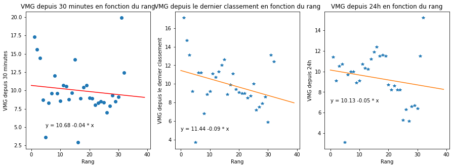

```python
# study of the linear regresison between two variables
plt.figure(1, figsize=(15, 5))
plt.subplot(131)
x = [i for i in range(0,40)]
plt.scatter(rang, VMG_30m)
d = np.polyfit(rang,VMG_30m,1)
f = np.poly1d(d)
plt.plot(x, f(x),color='red')
equation = f'y = {round(f[0],2)} {round(f[1],2)} * x'
plt.text(5,5,equation);
plt.title('VMG depuis 30 minutes en fonction du rang', fontSize=12)
plt.xlabel('Rang')
plt.ylabel('VMG depuis 30 minutes')

plt.subplot(132)
plt.plot(rang, VMG_dernier, '*')
d = np.polyfit(rang,VMG_dernier,1)
f = np.poly1d(d)
plt.plot(x, f(x))
equation = f'y = {round(f[0],2)} {round(f[1],2)} * x'
plt.text(0,5,equation);
plt.title('VMG depuis le dernier classement en fonction du rang', fontsize=12)
plt.xlabel('Rang')
plt.ylabel('VMG depuis le dernier classement')

plt.subplot(133)
plt.plot(rang, VMG_24h, '*')
d = np.polyfit(rang,VMG_24h,1)
f = np.poly1d(d)
p2 = plt.plot(x, f(x))
equation = f'y = {round(f[0],2)} {round(f[1],2)} * x'
plt.text(0,7,equation);
plt.title('VMG depuis 24h en fonction du rang', fontSize=12)
plt.xlabel('Rang')
plt.ylabel('VMG depuis 24h');
```

**From the graph, we saw that globally VMG and rank have a negative relation which is coherent with correlation coefficients. Moreover, VMG since last rank gives the best performance where points are less dispersed around the linear regression curve.**

**We say that VMG since last rank is a best criterion to decide the rank of each skipper, because VMG since 30 minutes or since 24h may vary based on skipper's strategy. However, VMG since last rank is relatively stable and gives us an average performance of each skipper, it can be a representation of a skipper's performance.**

### b. From all rank files

```python
# data preparation:
rang_global = df['Rang']
VMG_30m_global = df['Depuis 30 minutes']['VMG / kts']
VMG_dernier_global = df['Depuis le dernier classement']['VMG / kts']
VMG_24h_global = df['Depuis 24 heures']['VMG / kts']
```

```python
# study correlation between rank and VMG
corr_30m_global = rang_global.corr(VMG_30m_global, method='pearson')
corr_dernier_global = rang_global.corr(VMG_dernier_global, method='pearson')
corr_24h_global = rang_global.corr(VMG_24h_global, method='pearson')
print('Pearson’s r Value Correlation Between rang and VMG depuis 30 minutes est', round(corr_30m_global,2),
     '\nPearson’s r Value Correlation Between rang and VMG depuis le dernier classement est', round(corr_dernier_global,2),
     '\nPearson’s r Value Correlation Between rang and VMG depuis 24 heures est', round(corr_24h_global,2))
```

```
Pearson’s r Value Correlation Between rang and VMG depuis 30 minutes est -0.34
Pearson’s r Value Correlation Between rang and VMG depuis le dernier classement est -0.38
Pearson’s r Value Correlation Between rang and VMG depuis 24 heures est -0.42
```

**Here, we use all historical rank files, so that we have a bigger dataset. In this case, the difference among three values is not that obvious. We saw that all coefficient values are around -0.3-0.4.**

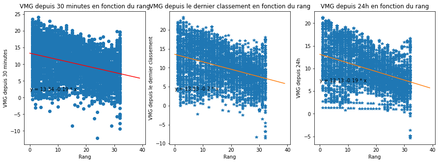

```python
# study of the linear regresison between two variables
plt.figure(1, figsize=(15, 5))
plt.subplot(131)
x = [i for i in range(0,40)]
plt.scatter(rang_global, VMG_30m_global)
d = np.polyfit(rang_global,VMG_30m_global,1)
f = np.poly1d(d)
plt.plot(x, f(x),color='red')
equation = f'y = {round(f[0],2)} {round(f[1],2)} * x'
plt.text(0,2,equation);
plt.title('VMG depuis 30 minutes en fonction du rang', fontSize=12)
plt.xlabel('Rang')
plt.ylabel('VMG depuis 30 minutes')

plt.subplot(132)
plt.plot(rang_global, VMG_dernier_global, '*')
d = np.polyfit(rang_global, VMG_dernier_global, 1)
f = np.poly1d(d)
plt.plot(x, f(x))
equation = f'y = {round(f[0], 2)} {round(f[1], 2)} * x'
plt.text(0,4,equation);
plt.title('VMG depuis le dernier classement en fonction du rang', fontsize=12)
plt.xlabel('Rang')
plt.ylabel('VMG depuis le dernier classement')

plt.subplot(133)
plt.plot(rang_global, VMG_24h_global, '*')
d = np.polyfit(rang_global,VMG_24h_global,1)
f = np.poly1d(d)
p2 = plt.plot(x, f(x))
equation = f'y = {round(f[0],2)} {round(f[1],2)} * x'
plt.text(0,7,equation);
plt.title('VMG depuis 24h en fonction du rang', fontSize=12)
plt.xlabel('Rang')
plt.ylabel('VMG depuis 24h');
```

**From the graph, we can again prove our observation above: globally VMG and rank have a negative relation. All points are dispersed around the linear regression curve. We could say that bigger the VGM is, better the skipper's rank is.**

## 2. Impact de la présence d'un foil sur le classement et la vitesse des voiliers

```python
# preparation of the data
sans_foil = df.loc[((df['Nombre de dérives'] == '2') | (df['Nombre de dérives'] == '2 asymétriques'))]
avec_foil = df.loc[((df['Nombre de dérives'] == 'foils') | (df['Nombre de dérives'] == 'foiler'))]
```

### a. Impact de la présence d'un foil sur le classement

```python
rang_sans_foil = sans_foil['Rang']
rang_avec_foil = avec_foil['Rang']
```

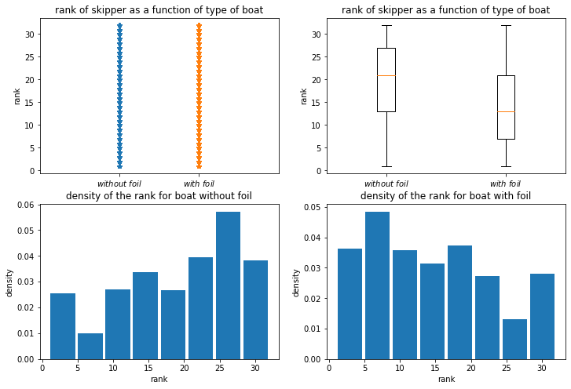

```python
# visulisation of influence
plt.figure(1, figsize=(12, 8))
plt.subplot(221)
x = [0]*(rang_sans_foil.shape[0])
x2 = [1]*rang_avec_foil.shape[0]
plt.plot(x,rang_sans_foil,'*')
plt.plot(x2,rang_avec_foil,'*')
plt.xlim((-1,2))
plt.ylabel('rank')
plt.xticks([0,1],[r'$without\ foil$', r'$with\ foil$'])
plt.title('rank of skipper as a function of type of boat')

plt.subplot(222)
plt.boxplot((rang_sans_foil,rang_avec_foil))
plt.xticks([1,2],[r'$without\ foil$', r'$with\ foil$'])
plt.ylabel('rank')
plt.title('rank of skipper as a function of type of boat')

plt.subplot(223)
plt.hist(rang_sans_foil, bins=8, density=True, rwidth=0.9)
plt.xlabel('rank')
plt.ylabel('density')
plt.title('density of the rank for boat without foil')

plt.subplot(224)
plt.hist(rang_avec_foil, bins=8, density=True, rwidth=0.9)
plt.xlabel('rank')
plt.ylabel('density')
plt.title('density of the rank for boat with foil');
```

```python
print(f"For rank of skipper without foil: \nWe have 14 persons choosing boat without foil,\
      \nthe average of their rank is  {round(rang_sans_foil.mean(),2)}, \nthe median of their rank is  {rang_sans_foil.median()} \
      \nthe standard deviation of the rank is  {round(rang_sans_foil.std(),2)}")

print(f"\n\nFor rank of skipper with foil: \nWe have 18 persons choosing boat with foil,\
      \nthe average of their rank is  {round(rang_avec_foil.mean(),2)}, \nthe median of their rank is  {rang_avec_foil.median()} \
      \nthe standard deviation of the rank is  {round(rang_avec_foil.std(),2)}")
```

```
For rank of skipper without foil:
We have 14 persons choosing boat without foil,
the average of their rank is  19.22,
the median of their rank is  21.0
the standard deviation of the rank is  8.67


For rank of skipper with foil:
We have 18 persons choosing boat with foil,
the average of their rank is  14.55,
the median of their rank is  13.0
the standard deviation of the rank is  9.12
```

**From the graph above, we constate that more skippers choosed boat with foil and foil has a positive impact on the rank, as its average and meidan are better than its without foil. However, we also observe a larger dispersion for rank with foil, which may be caused by number of participants. As a conclusion, foil does influence on rank and it is more like a positive influence.**